# Cx4073 : Assignment 1

Chiripal Vansh Jaiprakash

U1622893A

### Analysis of Naval Propulsion Data

Import the CSV data file `assign1_NavalData.csv` for analysis, and quickly check the structure of the data.

```r
install.packages("corrplot", repos = "https://cran.asia/")
install.packages("ggfortify", repos = "https://cran.asia/")
install.packages("randomForest", repos = "https://cran.asia/")
install.packages("miscTools", repos = "https://cran.asia/")
install.packages("FNN", repos = "https://cran.asia/")
install.packages("extraTrees", repos = "https://cran.asia/")
rm(list = ls())
# Importing the Dataset Naval Data
# There are 16 features and 2 outputs with 10,000 rows
navalData <- read.csv("assign1_NavalData.csv", header = TRUE)
# Structure of the dataset
str(navalData)
```

```
## 'data.frame':    10000 obs. of  18 variables:
##  $ X1 : num  3.14 7.15 5.14 4.16 9.3 9.3 2.09 1.14 8.21 8.21 ...
##  $ X2 : int  9 21 15 12 27 27 6 3 24 24 ...
##  $ X3 : num  8374 39007 21639 14722 72759 ...
##  $ X4 : num  1387 2678 1924 1547 3560 ...
##  $ X5 : num  7014 9116 8514 7758 9729 ...
##  $ X6 : num  60.3 332.5 175.3 113.8 644.7 ...
##  $ X7 : num  60.3 332.5 175.3 113.8 644.7 ...
##  $ X8 : num  586 822 705 653 1058 ...
##  $ X9 : int  288 288 288 288 288 288 288 288 288 288 ...
##  $ X10: num  578 687 640 610 772 ...
##  $ X11: num  1.39 2.99 2.07 1.66 4.55 4.52 1.33 1.26 3.6 3.58 ...
##  $ X12: int  1 1 1 1 1 1 1 1 1 1 ...
##  $ X13: num  7.6 15.71 10.92 9.01 22.96 ...
##  $ X14: num  1.02 1.04 1.03 1.02 1.05 1.05 1.02 1.02 1.04 1.04 ...
##  $ X15: num  12.3 44 24.9 17.8 88.3 ...
##  $ X16: num  0.24 0.87 0.49 0.35 1.75 1.79 0.26 0.25 1.18 1.22 ...
##  $ Y1 : num  0.99 0.99 0.95 0.97 1 0.97 0.99 0.99 1 0.96 ...
##  $ Y2 : num  0.98 0.98 1 0.98 0.98 0.98 1 0.99 0.99 0.98 ...
```

We find that data is stored in data.frame `X2`, `X9` and `X12` have integer datatype and the remaining are numeric data type The following table summarizes the features/variables in the dataset. You will also find them in the text file `assign1_FeatureNames.txt`. The features/variables `X1` to `X16` are the predictors, while `Y1` and `Y2` are the *target* response variables.

| Variable | Description |
| --- | --- |
| X1 | Lever position (lp) |
| X2 | Ship speed (v) [knots] |
| X3 | Gas Turbine shaft torque (GTT) [kN m] |
| X4 | Gas Turbine rate of revolutions (GTn) [rpm] |
| X5 | Gas Generator rate of revolutions (GGn) [rpm] |
| X6 | Starboard Propeller Torque (Ts) [kN] |
| X7 | Port Propeller Torque (Tp) [kN] |
| X8 | HP Turbine exit temperature (T48) [C] |
| X9 | GT Compressor inlet air temperature (T1) [C] |
| X10 | GT Compressor outlet air temperature (T2) [C] |
| X11 | HP Turbine exit pressure (P48) [bar] |
| X12 | GT Compressor inlet air pressure (P1) [bar] |
| X13 | GT Compressor outlet air pressure (P2) [bar] |
| X14 | Gas Turbine exhaust gas pressure (Pexh) [bar] |
| X15 | Turbine Injecton Control (TIC) [%] |
| X16 | Fuel flow (mf) [kg/s] |
| Y1 | GT Compressor decay state coefficient |
| Y2 | GT Turbine decay state coefficient |

The data is from a simulator of a naval vessel, characterized by a Gas Turbine (GT) propulsion plant. You may treat the available data as if it is from a hypothetical naval vessel. The propulsion system behaviour has been described with the parameters `X1` to `X16`, as detailed above, and the target is to predict the performance decay of the GT components such as *GT Compressor* and *GT Turbine*.

**Task** : Build the best possible Linear Model you can to predict both `Y1` and `Y2`, using the training dataset `assign1_NavalData.csv`. Then predict `Y1` and `Y2` values using your model on the test dataset `assign1_NavalPred.csv`.

### Exploratory Data Analysis

First, gather the summary of all the variables in the given dataset and draw inferences from it.

```r
summary(navalData)
```

```
##        X1              X2              X3                X4
##  Min.   :1.140   Min.   : 3.00   Min.   :  253.6   Min.   :1308
##  1st Qu.:3.140   1st Qu.: 9.00   1st Qu.: 8375.9   1st Qu.:1387
##  Median :5.140   Median :15.00   Median :21630.7   Median :1924
##  Mean   :5.162   Mean   :14.98   Mean   :27160.0   Mean   :2134
##  3rd Qu.:7.150   3rd Qu.:21.00   3rd Qu.:39001.2   3rd Qu.:2678
##  Max.   :9.300   Max.   :27.00   Max.   :72783.3   Max.   :3561
##        X5             X6               X7               X8
##  Min.   :6589   Min.   :  5.30   Min.   :  5.30   Min.   : 444.7
##  1st Qu.:7058   1st Qu.: 60.32   1st Qu.: 60.32   1st Qu.: 590.0
##  Median :8482   Median :175.27   Median :175.27   Median : 706.0
##  Mean   :8198   Mean   :226.51   Mean   :226.51   Mean   : 734.9
##  3rd Qu.:9132   3rd Qu.:332.36   3rd Qu.:332.36   3rd Qu.: 833.6
##  Max.   :9797   Max.   :645.25   Max.   :645.25   Max.   :1115.8
##        X9           X10             X11             X12         X13
##  Min.   :288   Min.   :541.0   Min.   :1.090   Min.   :1   Min.   : 5.83
##  1st Qu.:288   1st Qu.:578.1   1st Qu.:1.390   1st Qu.:1   1st Qu.: 7.45
##  Median :288   Median :637.1   Median :2.080   Median :1   Median :11.09
##  Mean   :288   Mean   :646.0   Mean   :2.349   Mean   :1   Mean   :12.28
##  3rd Qu.:288   3rd Qu.:693.8   3rd Qu.:2.980   3rd Qu.:1   3rd Qu.:15.66
##  Max.   :288   Max.   :789.1   Max.   :4.560   Max.   :1   Max.   :23.14
##       X14            X15             X16               Y1
##  Min.   :1.02   Min.   : 0.00   Min.   :0.0700   Min.   :0.9500
##  1st Qu.:1.02   1st Qu.:14.12   1st Qu.:0.2500   1st Qu.:0.9600
##  Median :1.03   Median :25.27   Median :0.5000   Median :0.9800
##  Mean   :1.03   Mean   :33.56   Mean   :0.6607   Mean   :0.9757
##  3rd Qu.:1.04   3rd Qu.:44.53   3rd Qu.:0.8800   3rd Qu.:0.9900
##  Max.   :1.05   Max.   :92.56   Max.   :1.8300   Max.   :1.0000
##        Y2
##  Min.   :0.9800
##  1st Qu.:0.9800
##  Median :0.9900
##  Mean   :0.9885
##  3rd Qu.:0.9900
##  Max.   :1.0000
```

Statistical measures of each dimension providing a spread of the data among the 10,000 rows is returned that can help detect outliers and make relevant conclusions about the dataset.

**Data Visualisation**

Constructing histograms can help identify the distribution of the variables better.

```r
# Array for color codes
colnames(navalData)[3]
```

```
## [1] "X3"
```

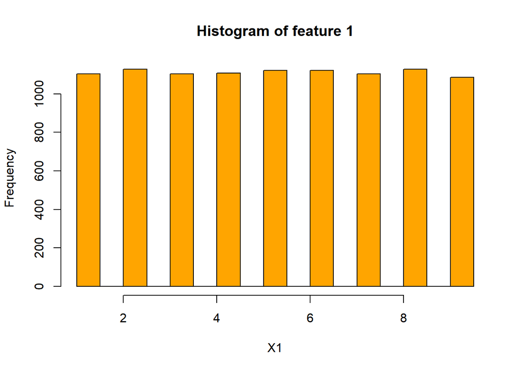

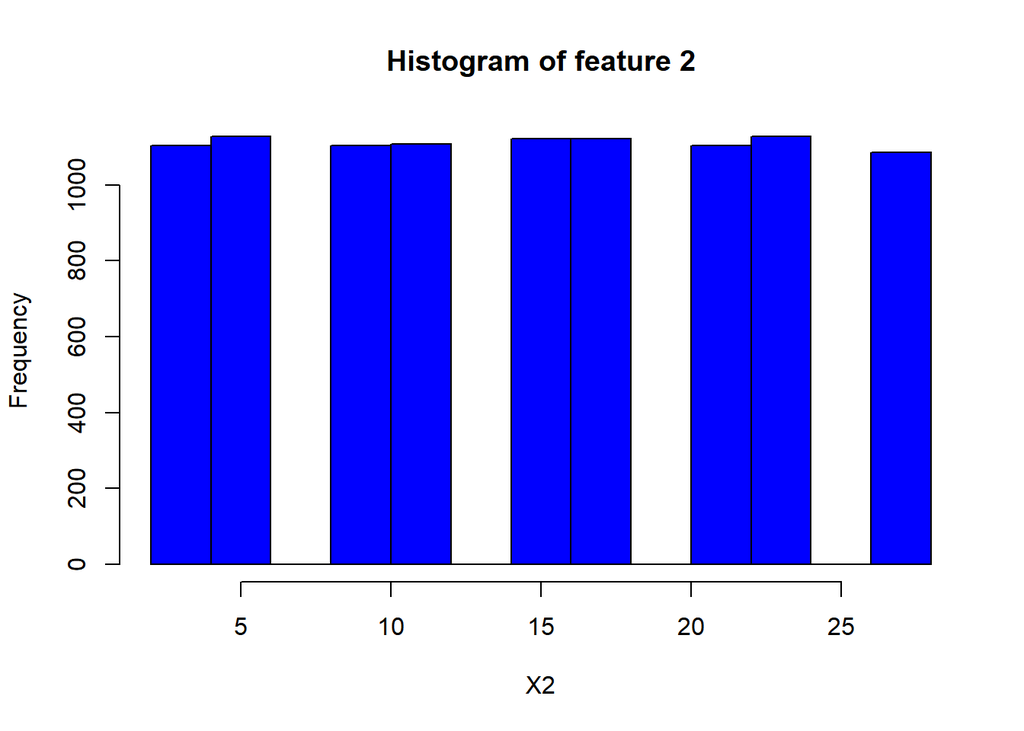

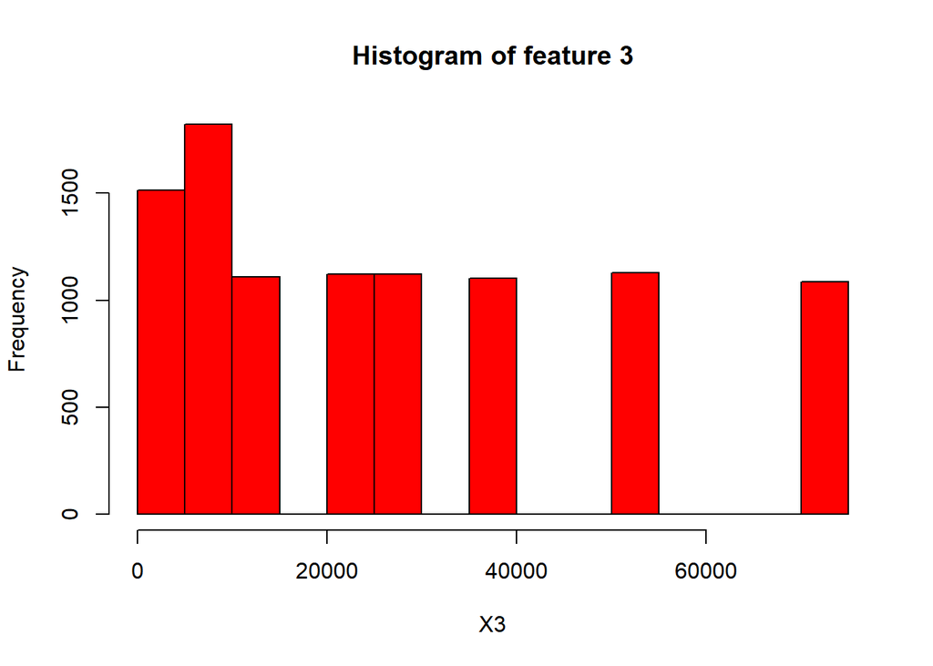

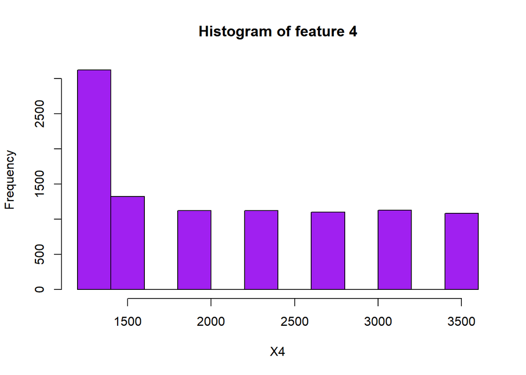

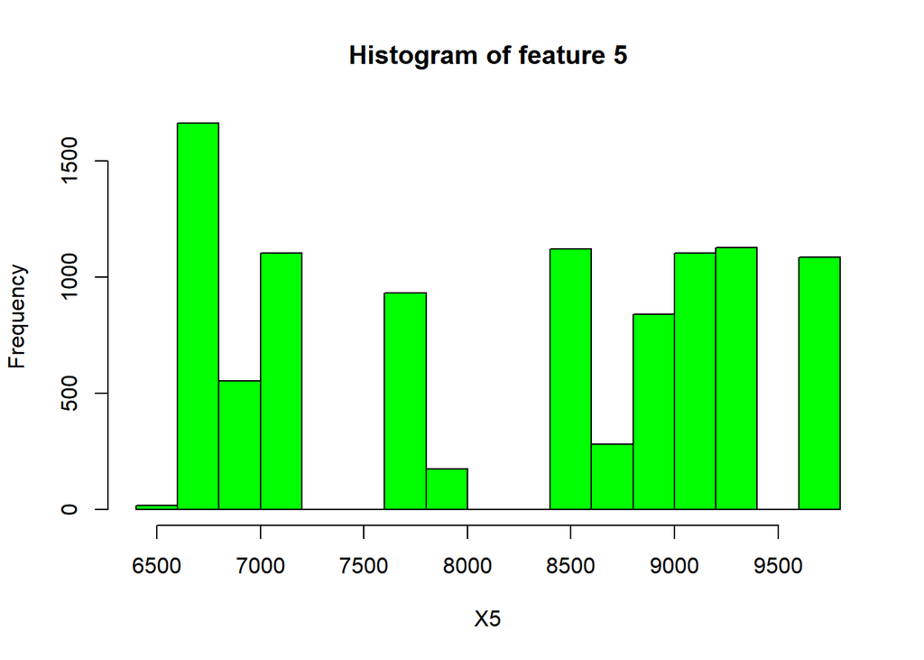

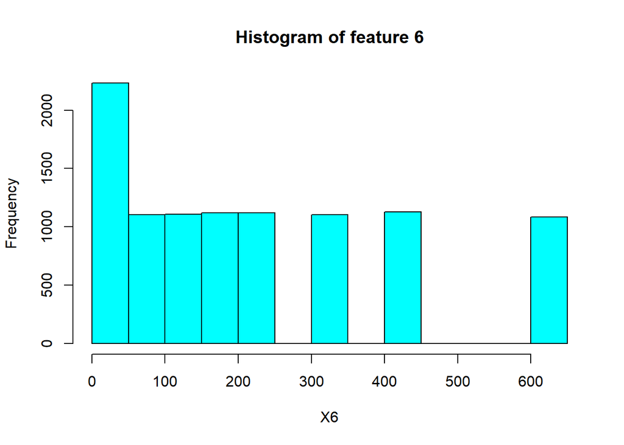

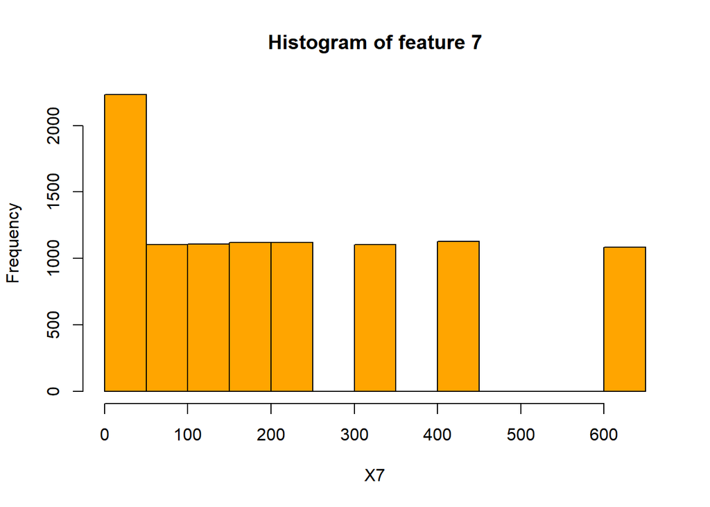

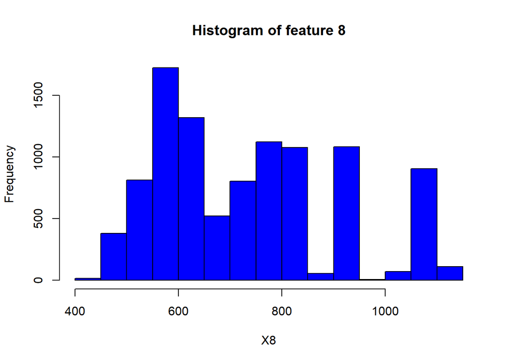

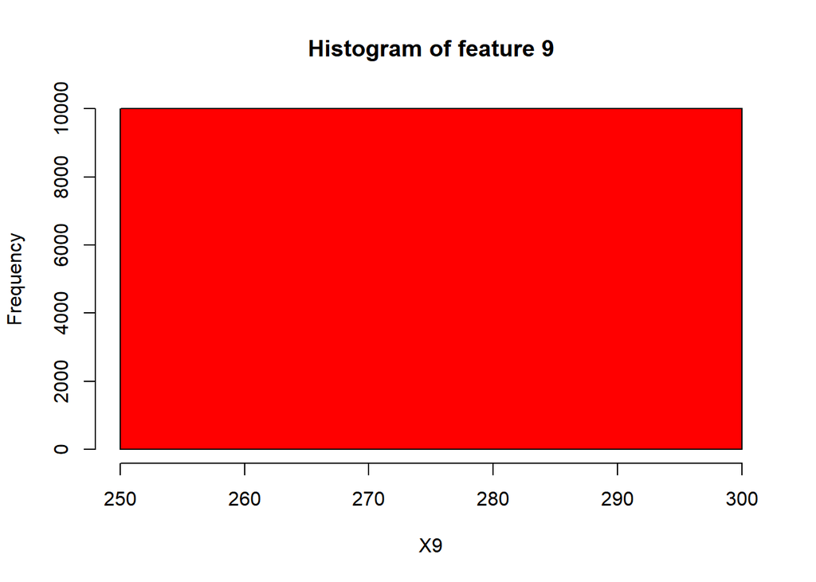

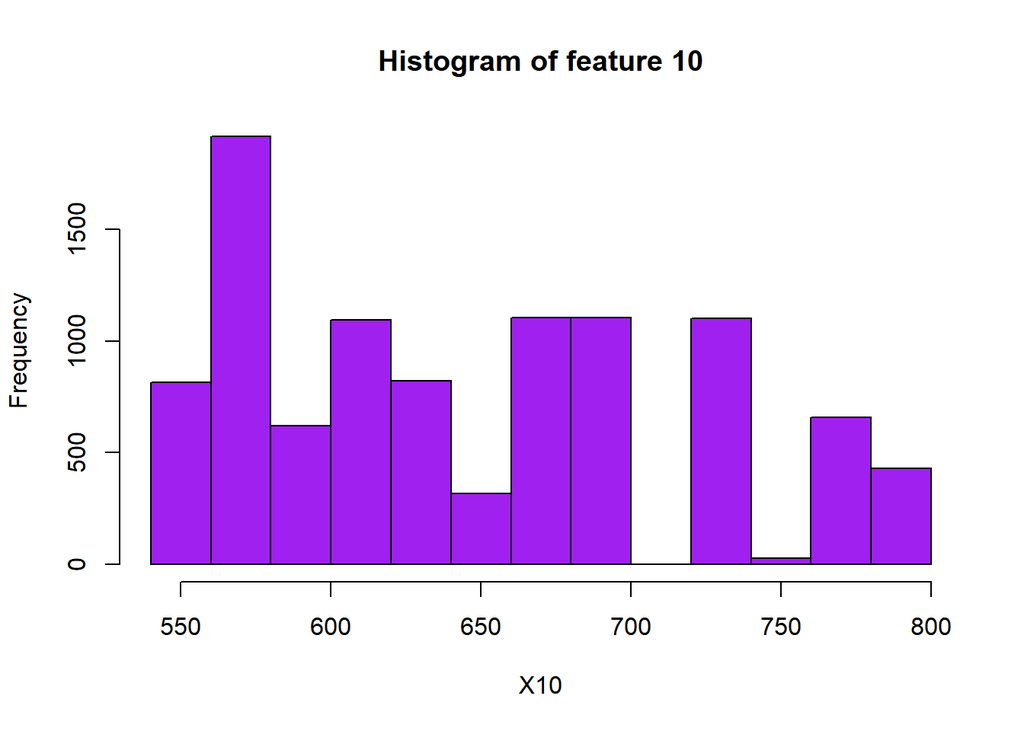

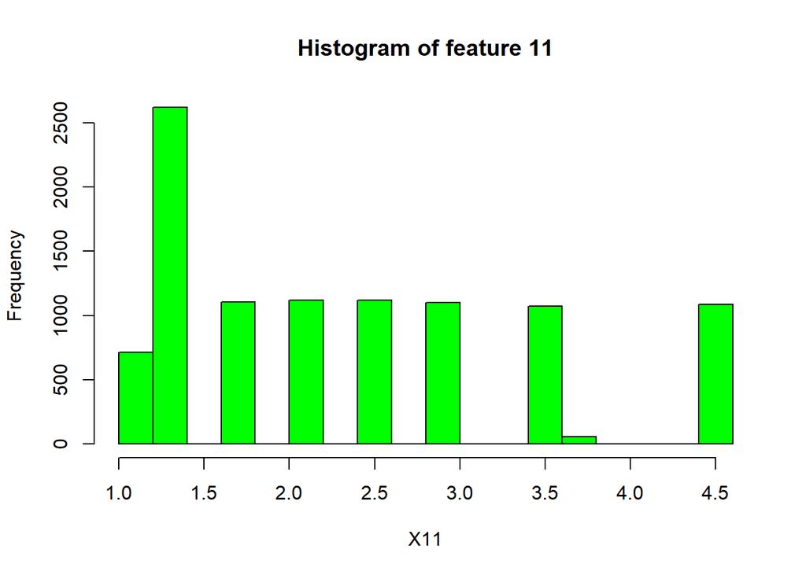

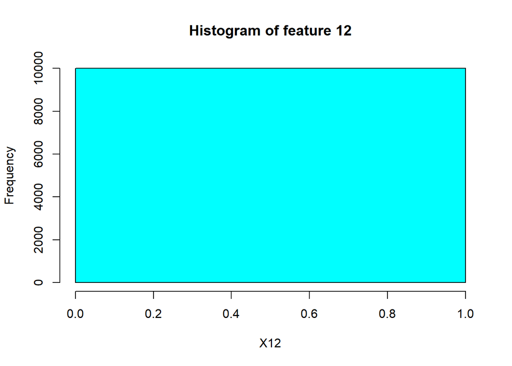

[6 more figures not shown]

```r
colorCode <- c("orange","blue","red","purple","green","cyan")
# Run a loop for histogram creation
for(i in seq(0,17)){
  hist(navalData[[i+1]], col = colorCode[i%%6 + 1], main = paste("Histogram of feature",i+1, sep=" ", collapse = NULL), xlab=colnames(navalData)[i+1])
}
```

The next visualization tool is Boxplot.

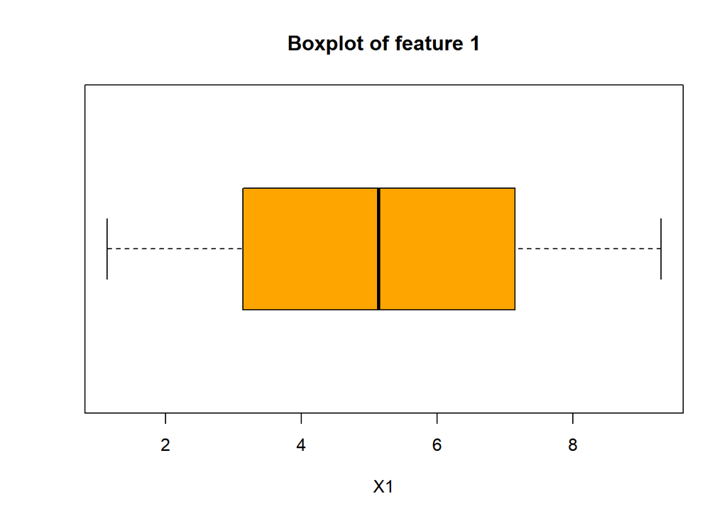

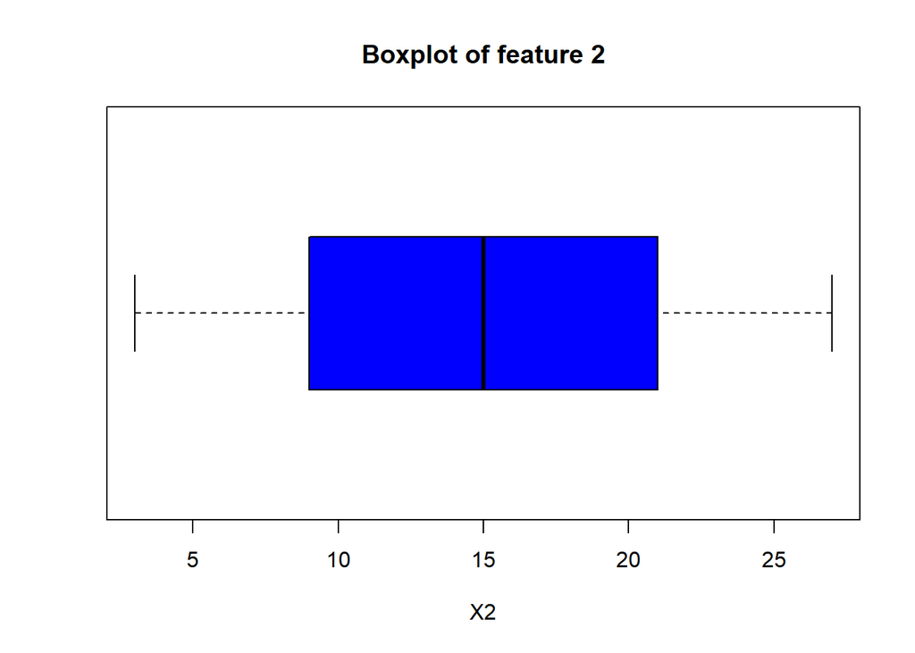

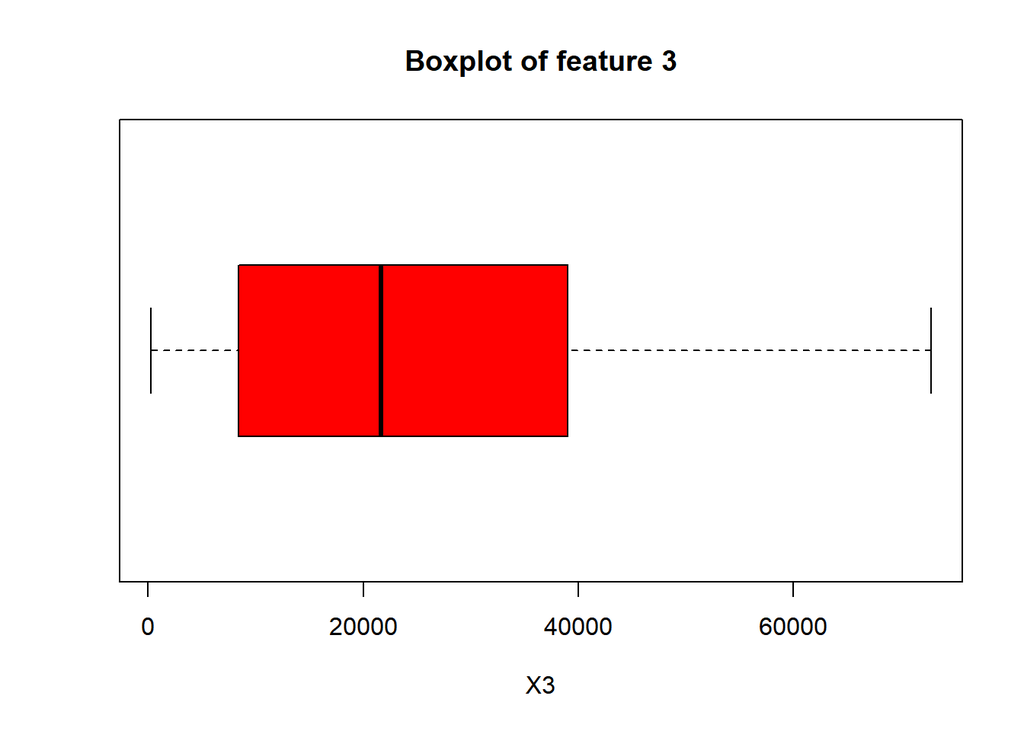

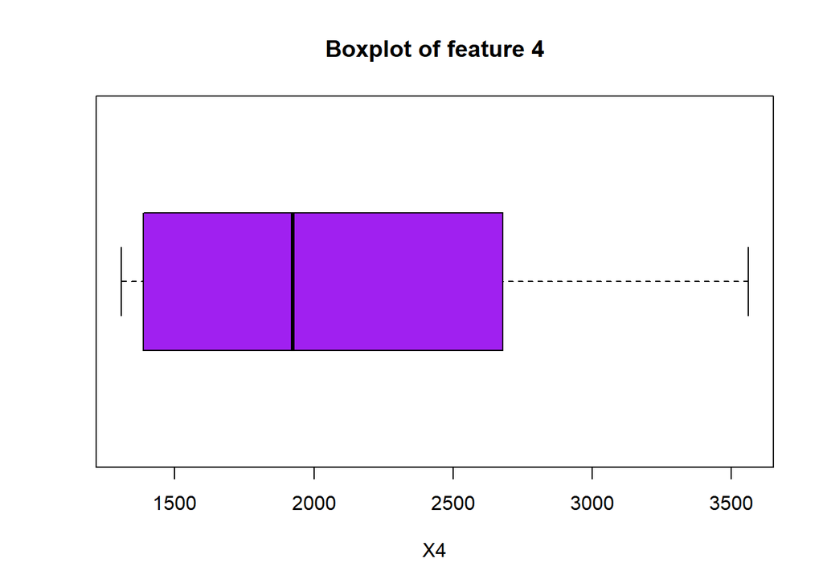

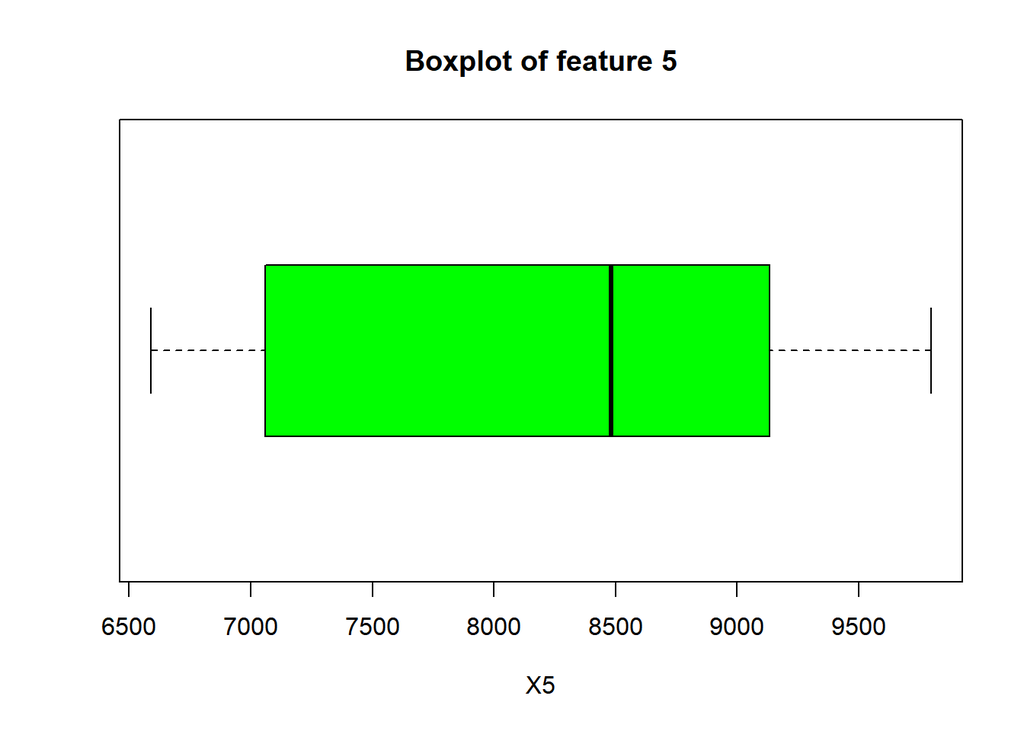

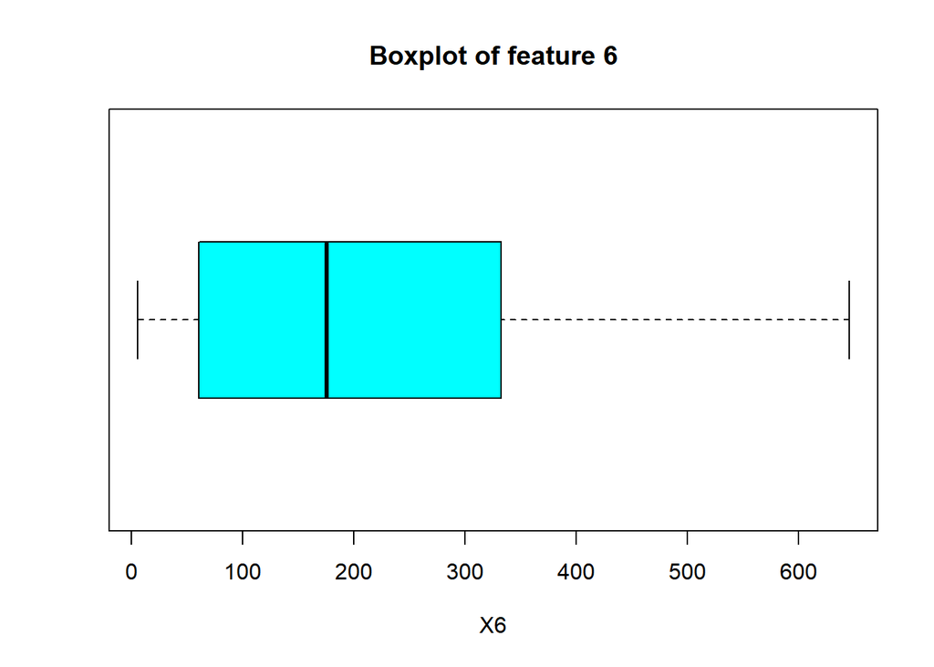

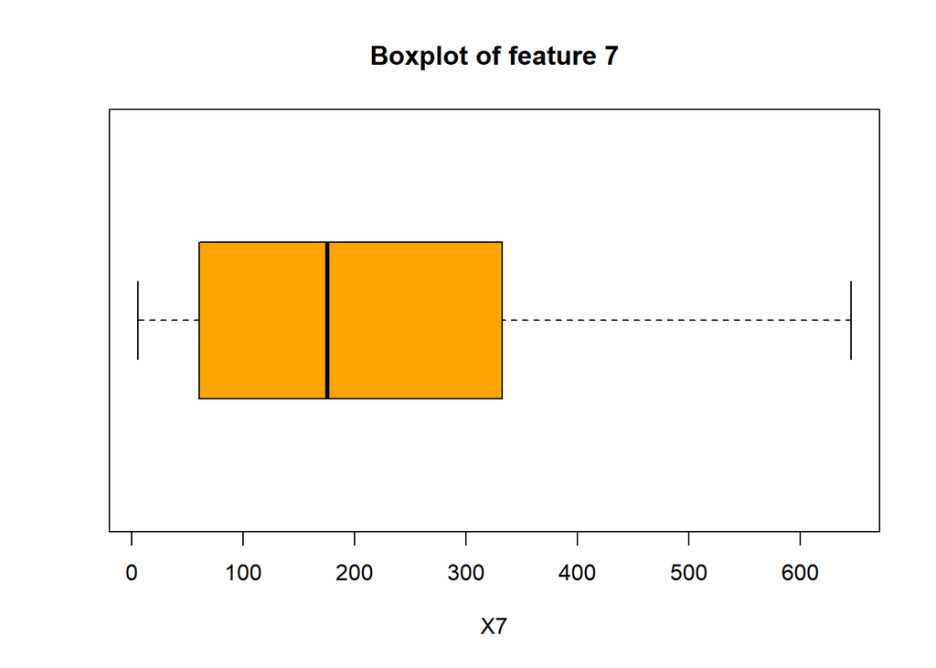

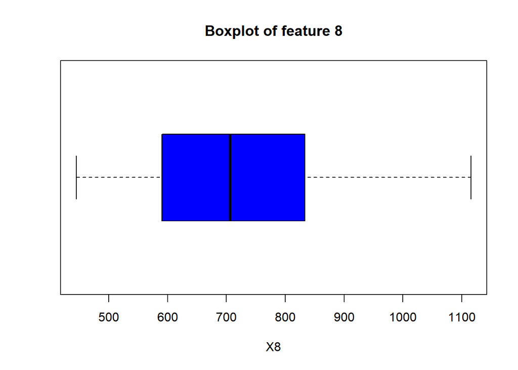

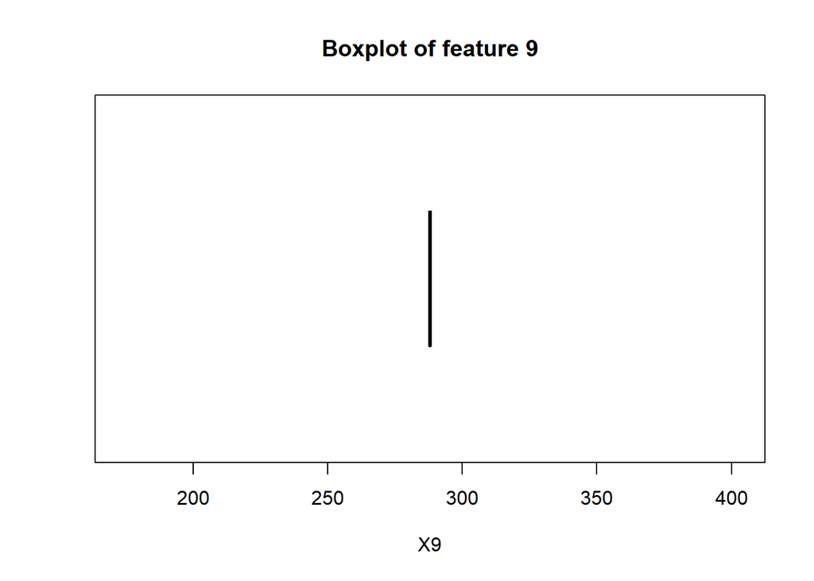

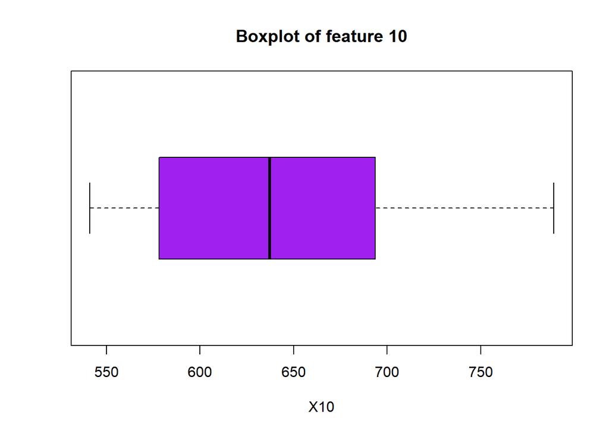

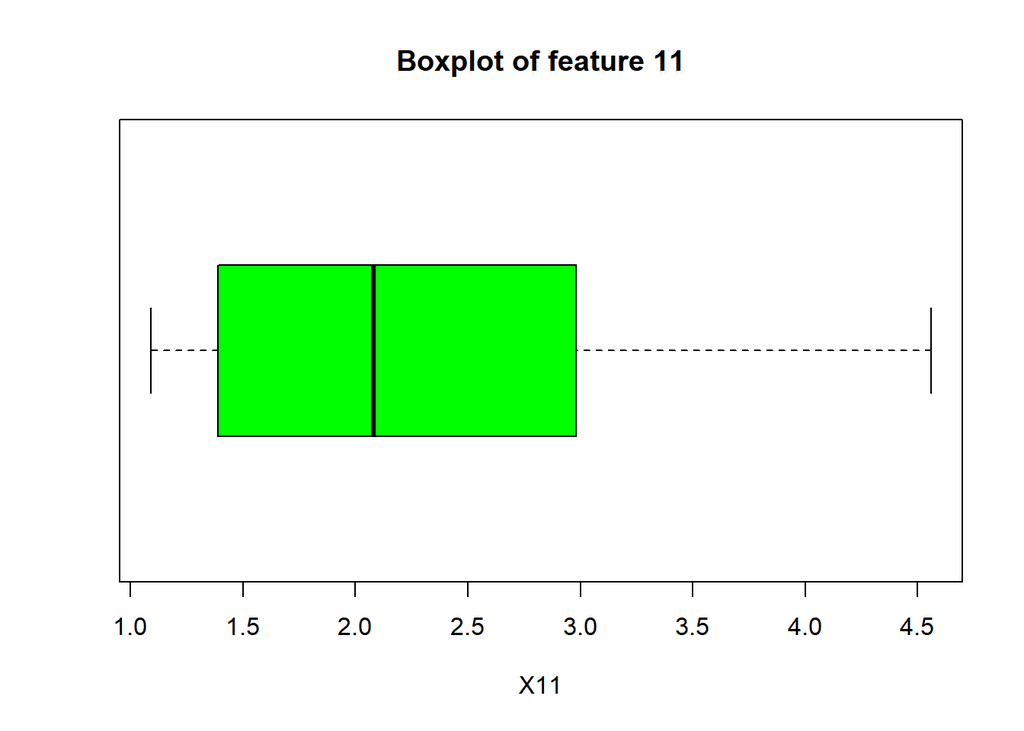

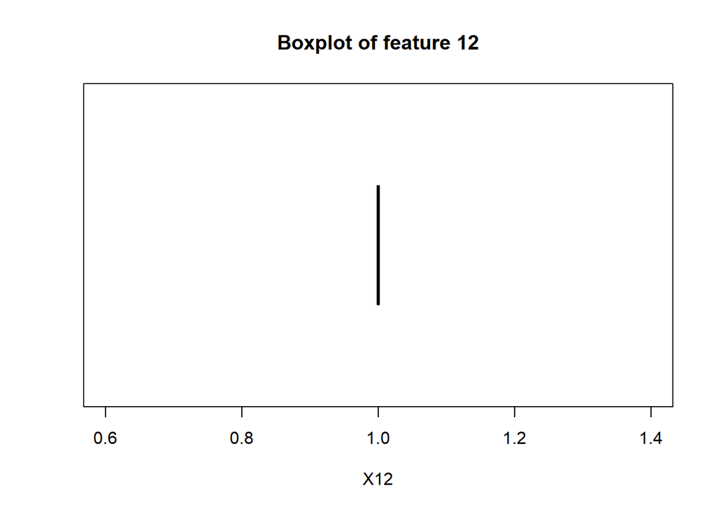

[6 more figures not shown]

```r
# Run a loop for boxplot creation
for(i in seq(0,17)){
  boxplot(navalData[[i+1]], horizontal = TRUE, col = colorCode[i%%6 + 1], main = paste("Boxplot of feature",i+1, sep=" ", collapse = NULL), xlab = colnames(navalData)[i+1])
}
```

```r
# Dropping columns X6, X9 and X12
navalDataFiltered = subset(navalData,select = -c(X6,X9,X12))
```

To perform in-depth analysis of interdependence between the features and the outputs, we need to find out the correlation between them.

```r
# Find correlation between variables and colormap
cor(navalDataFiltered)
```

```
##               X1           X2           X3           X4           X5
## X1   1.000000000  0.999918932  0.961060859  0.962170527  0.986018461
## X2   0.999918932  1.000000000  0.958307867  0.960416376  0.986548821
## X3   0.961060859  0.958307867  1.000000000  0.989710627  0.932836760
## X4   0.962170527  0.960416376  0.989710627  1.000000000  0.942750924
## X5   0.986018461  0.986548821  0.932836760  0.942750924  1.000000000
## X7   0.959275784  0.956445990  0.999172632  0.988613230  0.929454314
## X8   0.961363106  0.958975323  0.991117108  0.979605879  0.939689075
## X10  0.982901522  0.981293328  0.990183964  0.989218702  0.966616938
## X11  0.963095924  0.960647472  0.998888416  0.995108006  0.937287676
## X13  0.969167929  0.967014773  0.997576076  0.996031986  0.945731565
## X14  0.939948005  0.938787319  0.972969659  0.982595630  0.930584897
## X15  0.912781187  0.909186053  0.977483586  0.961994252  0.878080018
## X16  0.931333951  0.927768436  0.995035351  0.980197416  0.896626923
## Y1  -0.006831136 -0.006896537 -0.002047114 -0.003118643 -0.025153234
## Y2  -0.004758308 -0.004737331 -0.004087297 -0.004376194  0.005878501
##               X7          X8         X10          X11          X13          X14
## X1   0.959275784  0.96136311  0.98290152  0.963095924  0.969167929  0.939948005
## X2   0.956445990  0.95897532  0.98129333  0.960647472  0.967014773  0.938787319
## X3   0.999172632  0.99111711  0.99018396  0.998888416  0.997576076  0.972969659
## X4   0.988613230  0.97960588  0.98921870  0.995108006  0.996031986  0.982595630
## X5   0.929454314  0.93968908  0.96661694  0.937287676  0.945731565  0.930584897
## X7   1.000000000  0.98594120  0.98733461  0.997995101  0.996164013  0.972923822
## X8   0.985941204  1.00000000  0.99228188  0.989368313  0.990447825  0.961339751
## X10  0.987334609  0.99228188  1.00000000  0.991669537  0.994336058  0.967675185
## X11  0.997995101  0.98936831  0.99166954  1.000000000  0.999397450  0.978193788
## X13  0.996164013  0.99044783  0.99433606  0.999397450  1.000000000  0.978681796
## X14  0.972923822  0.96133975  0.96767519  0.978193788  0.978681796  1.000000000
## X15  0.977039542  0.96927553  0.95811467  0.975334806  0.971710488  0.949322120
## X16  0.994307212  0.98623588  0.97630253  0.992683665  0.989216457  0.964529281
## Y1  -0.004261568 -0.04428452 -0.05189850  0.002945739  0.003249422 -0.005631884
## Y2  -0.004578771 -0.03974577 -0.02004147 -0.006871948 -0.021517833 -0.002865694
##             X15         X16           Y1           Y2
## X1   0.91278119  0.93133395 -0.006831136 -0.004758308
## X2   0.90918605  0.92776844 -0.006896537 -0.004737331
## X3   0.97748359  0.99503535 -0.002047114 -0.004087297
## X4   0.96199425  0.98019742 -0.003118643 -0.004376194
## X5   0.87808002  0.89662692 -0.025153234  0.005878501
## X7   0.97703954  0.99430721 -0.004261568 -0.004578771
## X8   0.96927553  0.98623588 -0.044284518 -0.039745766
## X10  0.95811467  0.97630253 -0.051898504 -0.020041470
## X11  0.97533481  0.99268366  0.002945739 -0.006871948
## X13  0.97171049  0.98921646  0.003249422 -0.021517833
## X14  0.94932212  0.96452928 -0.005631884 -0.002865694
## X15  1.00000000  0.98533613 -0.035551428 -0.021399292
## X16  0.98533613  1.00000000 -0.017788588 -0.020441146
## Y1  -0.03555143 -0.01778859  1.000000000 -0.001220496
## Y2  -0.02139929 -0.02044115 -0.001220496  1.000000000
```

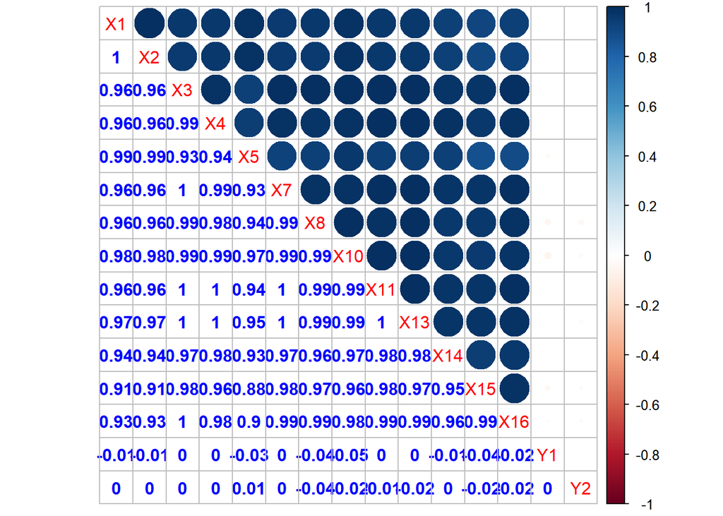

```r
library(corrplot)
corrplot.mixed(cor(navalDataFiltered), lower.col="blue")
```

The features are highly interdependent with strong correlation values (most > 0.8). The output values have minor but approximately similar dependence on all the input features. The high correlation for features like `X11` with most of the other features makes it comparatively less relevant in predicting output values.

### Model Building

The first step for building the model is splitting the data into train and test (using 80:20).

```r
set.seed(1)
# Split the data into 80:20 (train:test)
row.number <- sample(1:nrow(navalDataFiltered),0.8*nrow(navalDataFiltered))
train = navalDataFiltered[row.number,] # Init train
test  = navalDataFiltered[-row.number,] # Init test
```

The model built can be trained by Linear regression and other methods. Let us first examine the original dataset and train it and find out the accuracy of the model. **Adjusted R-squared** can be used to determine the performance of a model.

```r
# First linear model for Y1
lmFit1Y1 <- lm(Y1 ~ .,data = train[,-15])
summary(lmFit1Y1)
```

```
##
## Call:
## lm(formula = Y1 ~ ., data = train[, -15])
##
## Residuals:
##        Min         1Q     Median         3Q        Max
## -0.0180951 -0.0041676  0.0000462  0.0042030  0.0197351
##
## Coefficients:
##               Estimate Std. Error  t value Pr(>|t|)
## (Intercept)  4.798e+00  7.322e-02   65.518   <2e-16 ***
## X1           1.441e-01  6.496e-03   22.182   <2e-16 ***
## X2          -3.973e-02  2.043e-03  -19.449   <2e-16 ***
## X3          -3.527e-06  4.084e-07   -8.637   <2e-16 ***
## X4          -2.190e-08  3.328e-06   -0.007    0.995
## X5           4.209e-05  9.779e-07   43.037   <2e-16 ***
## X7          -5.629e-04  3.645e-05  -15.444   <2e-16 ***
## X8           2.888e-04  2.234e-05   12.931   <2e-16 ***
## X10         -4.162e-03  4.111e-05 -101.242   <2e-16 ***
## X11          2.089e-01  9.401e-03   22.224   <2e-16 ***
## X13          1.398e-02  9.600e-04   14.563   <2e-16 ***
## X14         -2.278e+00  6.816e-02  -33.413   <2e-16 ***
## X15         -6.200e-04  2.005e-05  -30.931   <2e-16 ***
## X16          1.332e-01  1.209e-02   11.018   <2e-16 ***
## ---
## Signif. codes:  0 '***' 0.001 '**' 0.01 '*' 0.05 '.' 0.1 ' ' 1
##
## Residual standard error: 0.006139 on 7986 degrees of freedom
## Multiple R-squared:  0.8397, Adjusted R-squared:  0.8394
## F-statistic:  3217 on 13 and 7986 DF,  p-value: < 2.2e-16
```

```r
lmFit2Y1 <- update(lmFit1Y1, ~ . - X4, data = train[,-15]) # Update model by removing X4
summary(lmFit2Y1)
```

```
##
## Call:
## lm(formula = Y1 ~ X1 + X2 + X3 + X5 + X7 + X8 + X10 + X11 + X13 +
##     X14 + X15 + X16, data = train[, -15])
##
## Residuals:
##        Min         1Q     Median         3Q        Max
## -0.0180949 -0.0041677  0.0000463  0.0042026  0.0197351
##
## Coefficients:
##               Estimate Std. Error  t value Pr(>|t|)
## (Intercept)  4.798e+00  6.892e-02   69.614   <2e-16 ***
## X1           1.441e-01  6.348e-03   22.703   <2e-16 ***
## X2          -3.973e-02  2.010e-03  -19.767   <2e-16 ***
## X3          -3.527e-06  4.006e-07   -8.803   <2e-16 ***
## X5           4.209e-05  9.113e-07   46.186   <2e-16 ***
## X7          -5.629e-04  3.642e-05  -15.453   <2e-16 ***
## X8           2.888e-04  2.226e-05   12.973   <2e-16 ***
## X10         -4.162e-03  3.403e-05 -122.318   <2e-16 ***
## X11          2.089e-01  8.108e-03   25.764   <2e-16 ***
## X13          1.398e-02  9.568e-04   14.611   <2e-16 ***
## X14         -2.278e+00  6.659e-02  -34.207   <2e-16 ***
## X15         -6.200e-04  1.996e-05  -31.056   <2e-16 ***
## X16          1.332e-01  1.148e-02   11.604   <2e-16 ***
## ---
## Signif. codes:  0 '***' 0.001 '**' 0.01 '*' 0.05 '.' 0.1 ' ' 1
##
## Residual standard error: 0.006139 on 7987 degrees of freedom
## Multiple R-squared:  0.8397, Adjusted R-squared:  0.8394
## F-statistic:  3486 on 12 and 7987 DF,  p-value: < 2.2e-16
```

The adjusted R square value stayed the same, which means there was no degradation in the performance. We have covered the linearity part and kept variables with significantly low values of Probability (Pr).

**Non-linearity**

Now, to check the non-linearity behaviour of the model, we use the package ggfortify to plot diagnostic plots.

```r
library(ggfortify)
```

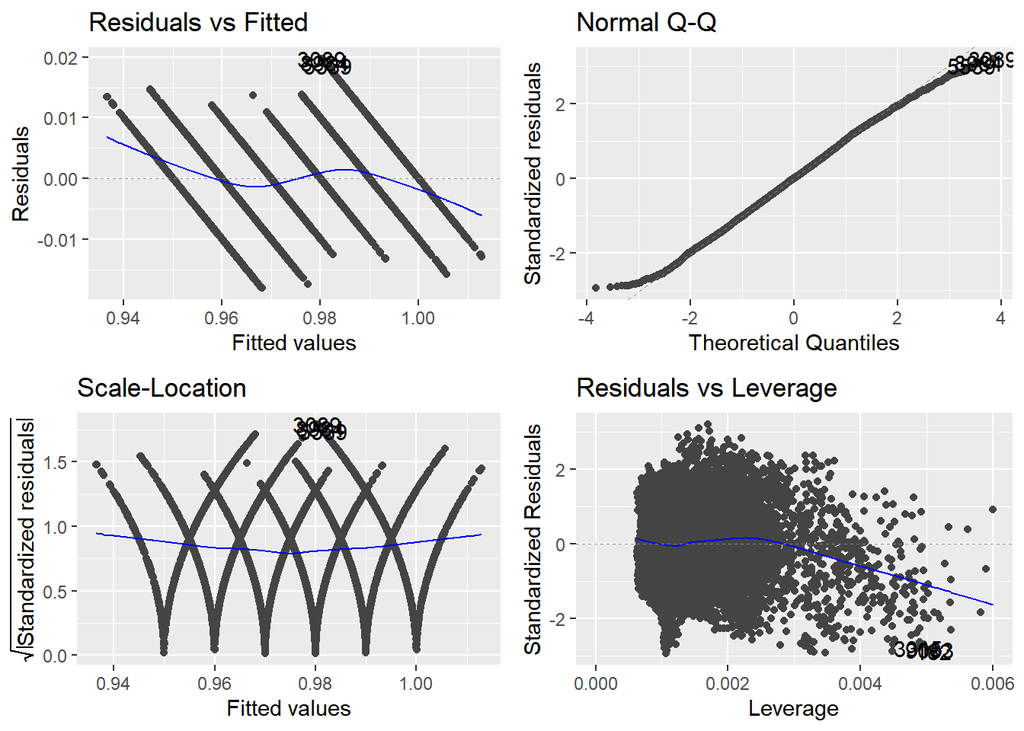

```r
autoplot(lmFit2Y1) # Plot diagnostic plots
```

The first plot gives us a good idea about the linearity of the values.

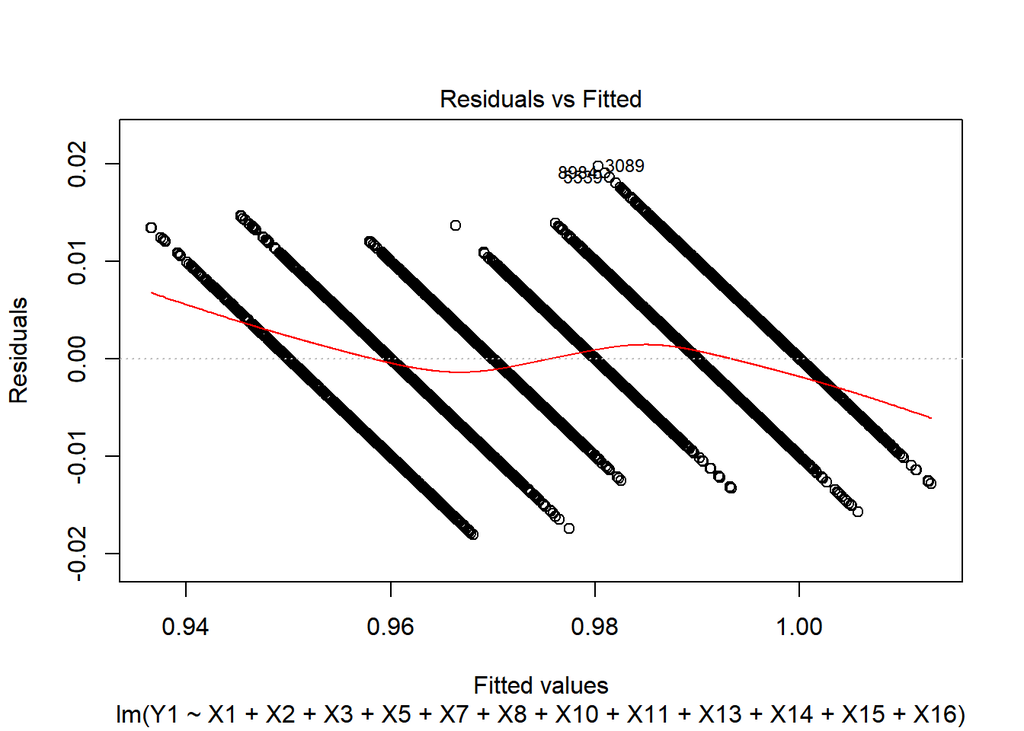

```r
plot(lmFit2Y1, 1)
```

In an ideal case, the red line in the center would be overlapping the horizontal dashed line. The model has average linear performance as the red line is approximately fitted with the dashed line. In order to improve the linearity, one can understand relationships between the independent and the dependent variables and interpret the non linearity better.

We can plot the variables against Y1 for the given dataset.

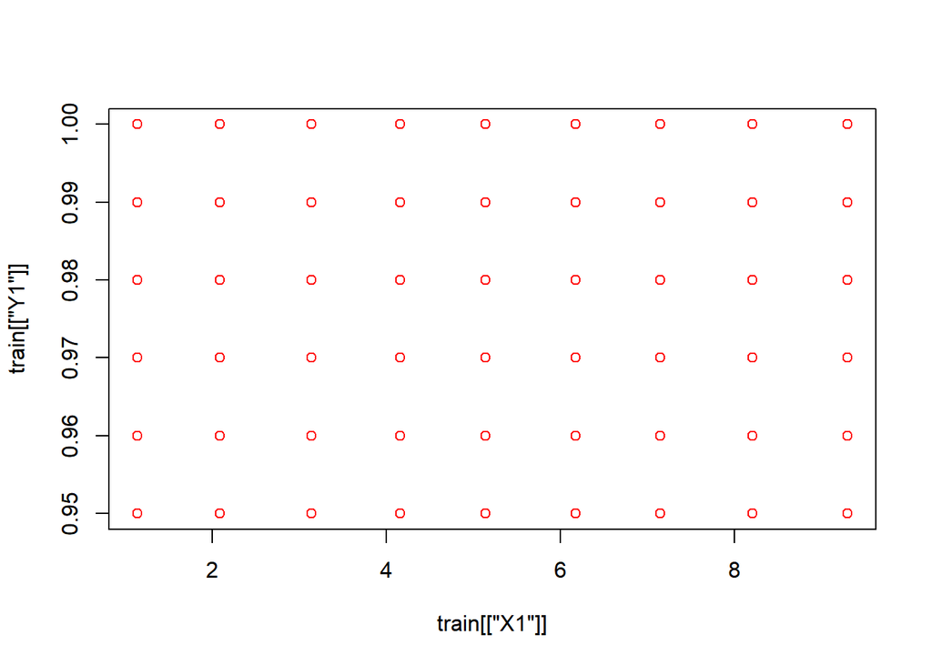

```r
plot(train[["X1"]],train[["Y1"]],pch=1,col="red")
```

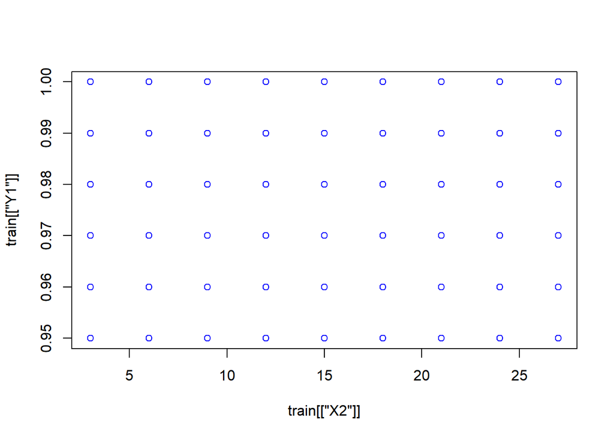

```r
plot(train[["X2"]],train[["Y1"]],pch=1,col="blue")
```

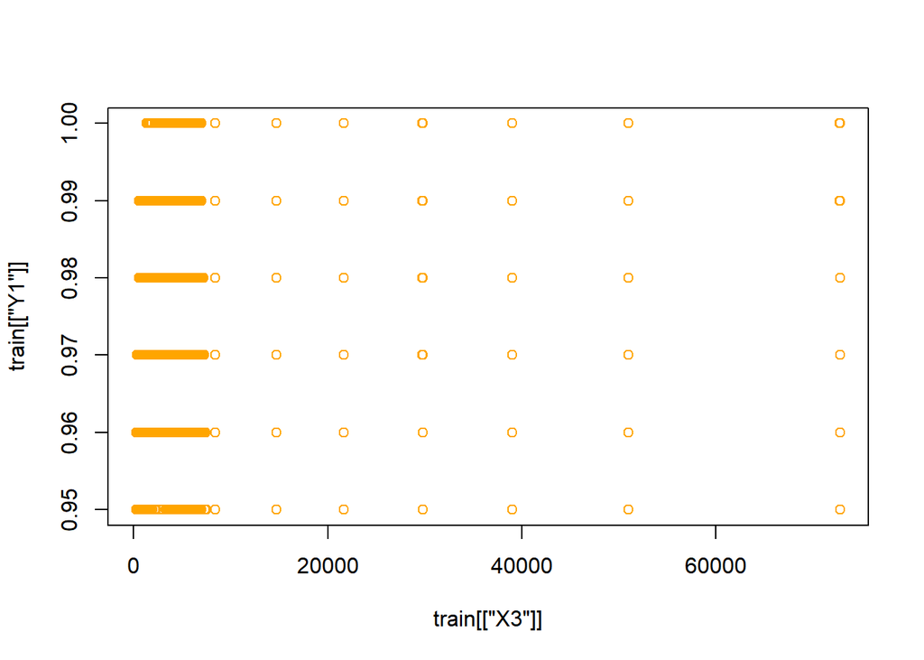

```r
plot(train[["X3"]],train[["Y1"]],pch=1,col="orange")
```